# ml-correlation-regression

# 23 Regression’ in the parlance of our time

In an opinion piece about nepotism published in The New York Times in 2015, economist Seth Stephens-Davidowitz wrote that:

‘Regression to the mean is so powerful that once-in-a-generation talent basically never sires once-in-a-generation talent. It explains why Michael Jordan’s sons were middling college basketball players and Jakob Dylan wrote two good songs. It is why there are no American parent-child pairs among Hall of Fame players in any major professional sports league.’

The author is arguing that…

Possible Answers Because of regression to the mean, an outstanding basketball player is likely to have sons that are as good at basketball as him.

Because of regression to the mean, an outstanding basketball player is likely to have sons that are not good at basketball.

Because of regression to the mean, an outstanding basketball player is likely to have sons that are good at basketball, but not as good as him. (answer)

Linear regression is incapable of evaluating musical or athletic talent.

# 24 Interpretation of regression coefficients

We’ve built our graphical intuition about regression and learned mathematical specification of them all. Now let’s learn the most important thing that is to interprete the regression coefficients using the textbook dataset for randomly selected courses. For each book we know the price at the ucla book store and amazon we also know the department and course number for each course and the isbn of the book.

```r
glimpse(textbooks)
```

```
## Observations: 73
## Variables: 7
## $ deptAbbr <fct> Am Ind, Anthro, Anthro, Anthro, Art His, Art His, Asi...
## $ course   <fct>  C170, 9, 135T, 191HB, M102K, 118E, 187B, 191E, C125,...
## $ ibsn     <fct> 978-0803272620, 978-0030119194, 978-0300080643, 978-0...
## $ uclaNew  <dbl> 27.67, 40.59, 31.68, 16.00, 18.95, 14.95, 24.70, 19.5...
## $ amazNew  <dbl> 27.95, 31.14, 32.00, 11.52, 14.21, 10.17, 20.06, 16.6...
## $ more     <fct> Y, Y, Y, Y, Y, Y, Y, N, N, Y, Y, N, Y, Y, N, N, N, N,...
## $ diff     <dbl> -0.28, 9.45, -0.32, 4.48, 4.74, 4.78, 4.64, 2.84, 17....
```

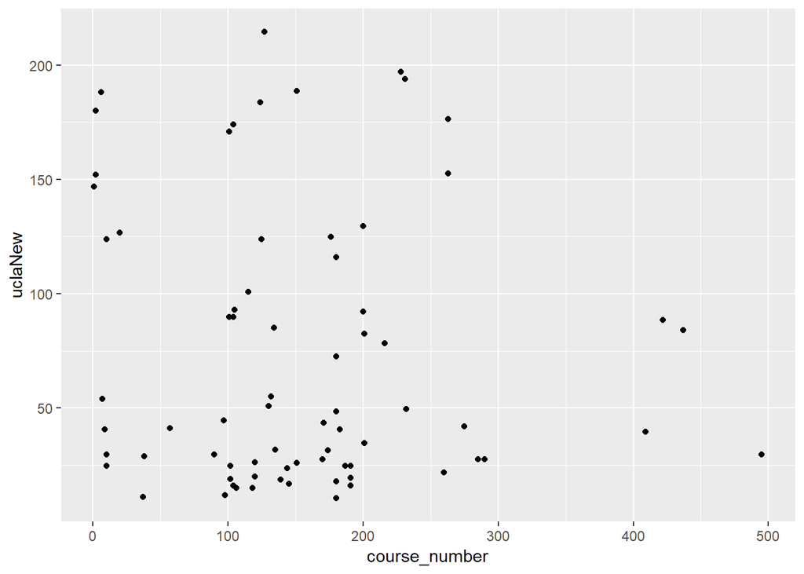

```r
# price comared to the course number of book
textbooks %>%
  mutate(course_number = readr::parse_number(course)) %>%
  ggplot(aes(x = course_number, y = uclaNew)) +
  geom_point()
```

This relationship is very weak- if anything it appears to be negative

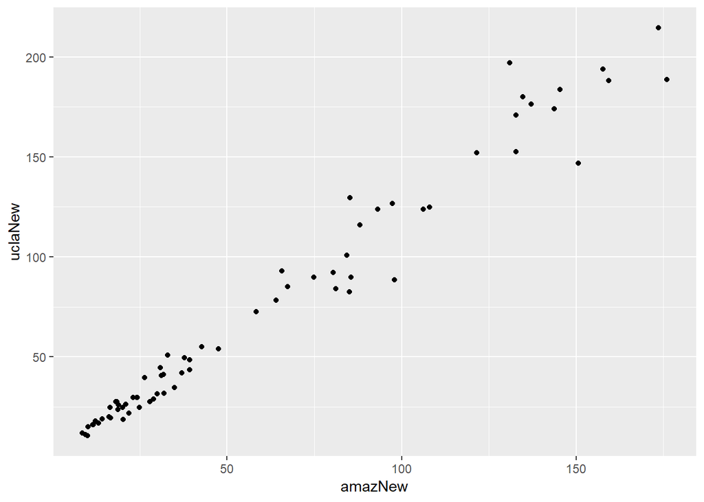

```r
# Let's compare the prices of these books at Amazon and ucla
ggplot(textbooks, aes(x = amazNew, y = uclaNew)) +
  geom_point()
```

Here we see a strong positive linear relationship

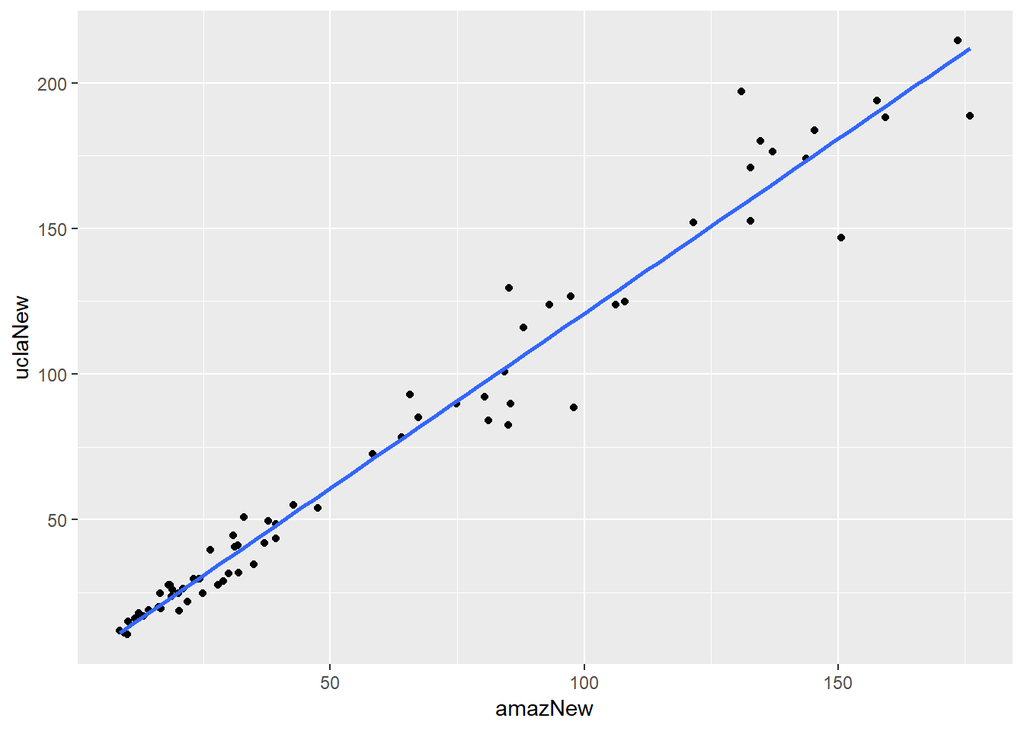

```r
# Add the regression line with geom_smooth command

ggplot(textbooks, aes(x = amazNew, y = uclaNew)) +
  geom_point() +
  geom_smooth(method = "lm", se = FALSE)
```

The regression line helps us to visualize the linear relationship but it doesn’t tell us what the fitted coefficients are

- to get those values we will use the lm command to fit them all
- we pass two arguments, one formula which specifies the reponse as function of explanatory variable and the data
- output coefficients beta0-hat = intercept = 0.929 usd beta1-hat = slope = 1.199 usd - 1 dollar 20 cents

interpretation - ucla charges 1 dollar 20 cents more for each each dollar that Amazon charges * so books at ucla are 20% higher than at Amazon

- generally we’re more interested in the slope coefficient

Always pay attention to units and scales * let’s convert dollars to cents and fit the model * the coefficients have changed * but the underlying meaning has not * here we say that for each additional cent that a book costs on amazon, the expected price at the ucla bookstore increases by 0.01199 dollars 0r 0.012 dollars * which is 1.2 cents as such it ucla price is 20 % higher on average than the price at Amazon.com

```r
lm(uclaNew ~ amazNew, data = textbooks)
```

```
##
## Call:
## lm(formula = uclaNew ~ amazNew, data = textbooks)
##
## Coefficients:
## (Intercept)      amazNew
##       0.929        1.199
```

```r
#Units and scale
textbooks %>%
  mutate(amazNew_cents = amazNew * 100) %>%
  lm(uclaNew ~ amazNew_cents, data = .)
```

```
##
## Call:
## lm(formula = uclaNew ~ amazNew_cents, data = .)
##
## Coefficients:
##   (Intercept)  amazNew_cents
##       0.92897        0.01199
```

Interpretation of coefficients

Recall that the fitted model for the poverty rate of U.S. counties as a function of high school graduation rate is:

Which of the following is the correct interpretation of the slope coefficient?

{

-0.6 ==> for each high school graduate poverty rate decreases by 0.6 }

Possible Answers Among U.S. counties, each additional percentage point increase in the poverty rate is associated with about a 0.591 percentage point decrease in the high school graduation rate.

Among U.S. counties, each additional percentage point increase in the high school graduation rate is associated with about a 0.591 percentage point decrease in the poverty rate. (answer)

Among U.S. counties, each additional percentage point increase in the high school graduation rate is associated with about a 0.591 percentage point increase in the poverty rate.

Among U.S. counties, a 1% increase in the high school graduation rate is associated with about a 0.591% decrease in the poverty rate.

Interpretation in context A politician interpreting the relationship between poverty rates and high school graduation rates implores his constituents:

If we can lower the poverty rate by 59%, we’ll double the high school graduate rate in our county (i.e. raise it by 100%).

Which of the following mistakes in interpretation has the politician made?

Possible Answers Implying that the regression model establishes a cause-and-effect relationship.

Switching the role of the response and explanatory variables.

Confusing percentage change with percentage point change.

All of the above. (answer)

None of the above.

Fitting simple linear models

While the geom_smooth(method = ‘lm’) function is useful for drawing linear models on a scatterplot, it doesn’t actually return the characteristics of the model. As suggested by that syntax, however, the function that creates linear models is lm(). This function generally takes two arguments:

A formula that specifies the model A data argument for the data frame that contains the data you want to use to fit the model The lm() function return a model object having class ‘lm’. This object contains lots of information about your regression model,

- including the data used to fit the model,
- the specification of the model,
- the fitted values and
- residuals, etc.

Using the bdims dataset, create a linear model for the weight of people as a function of their height.

```r
names(bdims)
```

```
##  [1] "bia.di" "bii.di" "bit.di" "che.de" "che.di" "elb.di" "wri.di"
##  [8] "kne.di" "ank.di" "sho.gi" "che.gi" "wai.gi" "nav.gi" "hip.gi"
## [15] "thi.gi" "bic.gi" "for.gi" "kne.gi" "cal.gi" "ank.gi" "wri.gi"
## [22] "age"    "wgt"    "hgt"    "sex"
```

```r
# wgt ~ hgt
# y = wgt, x = hgt

model_lm = lm(wgt ~ hgt, data = bdims)

model_lm
```

```
##
## Call:
## lm(formula = wgt ~ hgt, data = bdims)
##
## Coefficients:
## (Intercept)          hgt
##    -105.011        1.018
```

For every additional hgt wgt increases by 1

Using the mlbBat10 dataset, create a linear model for SLG as a function of OBP.

```r
names(mlbBat10)
```

```
##  [1] "name"     "team"     "position" "G"        "AB"       "R"
##  [7] "H"        "2B"       "3B"       "HR"       "RBI"      "TB"
## [13] "BB"       "SO"       "SB"       "CS"       "OBP"      "SLG"
## [19] "AVG"
```

```r
# SLG ~ OBP
# y = SLG, x = OBP

mlb_model_lm = lm(SLG ~ OBP, data = mlbBat10)

mlb_model_lm
```

```
##
## Call:
## lm(formula = SLG ~ OBP, data = mlbBat10)
##
## Coefficients:
## (Intercept)          OBP
##    0.009407     1.110323
```

For every additional OBP SLG increases by 1.11

Using the mammals dataset, create a linear model for the body weight of mammals as a function of their brain weight, after taking the natural log of both variables.

```r
names(mammals)
```

```
##  [1] "Species"     "BodyWt"      "BrainWt"     "NonDreaming" "Dreaming"
##  [6] "TotalSleep"  "LifeSpan"    "Gestation"   "Predation"   "Exposure"
## [11] "Danger"
```

```r
# BodyWt ~ BrainWt without log
# y = BodyWt, x = BrainWt
mammals_lm = lm(BodyWt ~ BrainWt, data = mammals)
mammals_lm
```

```
##
## Call:
## lm(formula = BodyWt ~ BrainWt, data = mammals)
##
## Coefficients:
## (Intercept)      BrainWt
##    -56.8555       0.9029
```

For every addtional BrainWt BodyWt increases by 1

```r
# BodyWt ~ BrainWt with log, log-linear model
mammals_llm = lm(log(BodyWt) ~ log(BrainWt), data = mammals)
mammals_llm
```

```
##
## Call:
## lm(formula = log(BodyWt) ~ log(BrainWt), data = mammals)
##
## Coefficients:
##  (Intercept)  log(BrainWt)
##       -2.509         1.225
```

For every additional BrainWt BodyWt increases by 1.2

# 25 Units and scale

In the previous examples, we fit two regression models:

and

Which of the following statements is incorrect?

Possible Answers A person who is 170 cm tall is expected to weigh about 68 kg. { -105.011 + 1.018*170 #[1] 68.049 } - this statemetn is correct

Because the slope coefficient for OBP is larger (1.110) than the slope coefficient for hgt (1.018), we can conclude that the association between OBP and SLG is stronger than the association between height and weight.

- infact opposite, a higher slope indicates an additional change in x (explanatory variable) will cause more change in y (response variable)

Your linear model object

- so far we have only printed the lm object to console
- the output of lm is an object and there are a lot of useful things we can do with that object
- note the output is an object of type ‘lm’
- it is not a dataframe, function, matrix or a list
- by default we see call when we print lm object and the fitted coefficients
- using coef(mod) we can retrieve the fitted coefficients which are the most important pieces of informatiion
- so regression can be considered as a descriptive statistical technique
- later we will learn inference from regression
- summary function on mod displays other information like residuals summary(mod)
- fitted.values(mod) returns a vector with y-hat value for each data point
- each observation corresponds to one value of y-hat, hence the length of the vector is same as nrow of dataset
- if length is not same then R has discarded values that cannot be fitted
- similarly, the fitted values generate residual values which is the difference between the actual observed value of the response variable and the expected value of the response according to our model
- these residuals can be retrieved using the residuals function residuals(mod) which returns the vector of residuals
- the R ecosystem is continuously evolving
- tool tidyverse has a package broom that helps to tidy up a bit
- in broom the augment function when called on our model returns a dataframe with original reponse and explanatory variable along with the fitted and residual values, leverage scores, etc
- using this we can do lot of work with our models after they are fit

The lm summary output An ‘lm’ object contains a host of information about the regression model that you fit. There are various ways of extracting different pieces of information.

The coef() function displays only the values of the coefficients. Conversely, the summary() function displays not only that information, but a bunch of other information, including the associated standard error and p-value for each coefficient, the R2, adjusted R2, and the residual standard error.

The summary of an ‘lm’ object in R is very similar to the output you would see in other statistical computing environments (e.g. Stata, SPSS, etc.)

```r
mod = lm(uclaNew ~ amazNew, data = textbooks)

class(mod)
```

```
## [1] "lm"
```

```r
coef(mod)
```

```
## (Intercept)     amazNew
##   0.9289651   1.1990014
```

```r
summary(mod)
```

```
##
## Call:
## lm(formula = uclaNew ~ amazNew, data = textbooks)
##
## Residuals:
##     Min      1Q  Median      3Q     Max
## -34.785  -4.574   0.577   4.012  39.002
##
## Coefficients:
##             Estimate Std. Error t value Pr(>|t|)
## (Intercept)  0.92897    1.93538    0.48    0.633
## amazNew      1.19900    0.02519   47.60   <2e-16 ***
## ---
## Signif. codes:  0 '***' 0.001 '**' 0.01 '*' 0.05 '.' 0.1 ' ' 1
##
## Residual standard error: 10.47 on 71 degrees of freedom
## Multiple R-squared:  0.9696, Adjusted R-squared:  0.9692
## F-statistic:  2266 on 1 and 71 DF,  p-value: < 2.2e-16
```

Fitted values and residuals Once you have fit a regression model, you are often interested in the fitted values (y^i) and the residuals (ei), where i indexes the observations. Recall that:

The least squares fitting procedure guarantees that the mean of the residuals is zero (n.b., numerical instability may result in the computed values not being exactly zero). At the same time, the mean of the fitted values must equal the mean of response variable.

In this exercise, we will confirm these two mathematical facts by accessing the fitted values and residuals with the fitted.values() and residuals() functions, respectively, for the following model:

```r
mod <- lm(wgt ~ hgt, data = bdims)

# Mean of weights equal to mean of fitted values?
mean(bdims$wgt) == mean(fitted.values(mod))
```

```
## [1] TRUE
```

```r
# Mean of the residuals
mean(residuals(mod))
```

```
## [1] -1.266971e-15
```

# 26 Tidying your linear model

As you fit a regression model, there are some quantities (e.g. R2) that apply to the model as a whole, while others apply to each observation (e.g. y^i). If there are several of these per-observation quantities, it is sometimes convenient to attach them to the original data as new variables.

The augment() function from the broom package does exactly this. It takes a model object as an argument and returns a data frame that contains the data on which the model was fit, along with several quantities specific to the regression model, including the fitted values, residuals, leverage scores, and standardized residuals

```r
# Load broom
library(broom)

# Create bdims_tidy
bdims_tidy = augment(mod)

# Glimpse the resulting data frame
glimpse(bdims_tidy)
```

```
## Observations: 507
## Variables: 9
## $ wgt        <dbl> 65.6, 71.8, 80.7, 72.6, 78.8, 74.8, 86.4, 78.4, 62....
## $ hgt        <dbl> 174.0, 175.3, 193.5, 186.5, 187.2, 181.5, 184.0, 18...
## $ .fitted    <dbl> 72.05406, 73.37697, 91.89759, 84.77427, 85.48661, 7...
## $ .se.fit    <dbl> 0.4320546, 0.4520060, 1.0667332, 0.7919264, 0.81834...
## $ .resid     <dbl> -6.4540648, -1.5769666, -11.1975919, -12.1742745, -...
## $ .hat       <dbl> 0.002154570, 0.002358152, 0.013133942, 0.007238576,...
## $ .sigma     <dbl> 9.312824, 9.317005, 9.303732, 9.301360, 9.312471, 9...
## $ .cooksd    <dbl> 5.201807e-04, 3.400330e-05, 9.758463e-03, 6.282074e...
## $ .std.resid <dbl> -0.69413418, -0.16961994, -1.21098084, -1.31269063,...
```

Using your linear model

- examining the residuals of textbook linear model we can determine if the books are over/under priced in comparison of ucla and amazon prices
- model can be used to make predictions for out of sample observations
- the predict function when applied to an lm object predict(lm), will return the fitted values for original observations by default
- if we pass the newdata argument we can predict for any observations we want predict(lm, newdata)
- newdata must be a similar dataframe
- the result is a vector of fitted values

```r
txtbk_mod = lm(uclaNew ~ amazNew, data = textbooks)

new_data = data.frame(amazNew = 8.49)

predict(txtbk_mod, newdata = new_data)
```

```
##        1
## 11.10849
```

it predicts it will sell for 11 dollars 11 cents at ucla store

Visualize new observations augment function can also take the newdata argument

```r
isrs = broom::augment(txtbk_mod, newdata = new_data)

glimpse(isrs)
```

```
## Observations: 1
## Variables: 3
## $ amazNew <dbl> 8.49
## $ .fitted <dbl> 11.10849
## $ .se.fit <dbl> 1.775048
```

This returns a new data frame of predicted value We can use this df to fit a regression line on the scatter plot of the original data and plot the predicted point in red fro the new data point

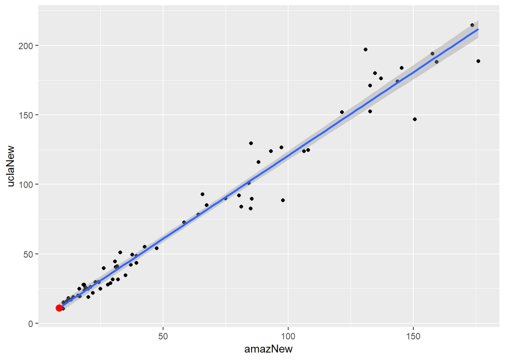

```r
ggplot(textbooks, aes(x = amazNew, y = uclaNew)) +
  geom_point() +
  geom_smooth(method = 'lm') +
  geom_point(data = isrs, aes(y = .fitted), size =3,
             color = 'red')
```

# 27 Making predictions

The fitted.values() function or the augment()-ed data frame provides us with the fitted values for the observations that were in the original data. However, once we have fit the model, we may want to compute expected values for observations that were not present in the data on which the model was fit. These types of predictions are called out-of-sample.

The ben data frame contains a height and weight observation for one person. The mod object contains the fitted model for weight as a function of height for the observations in the bdims dataset. We can use the predict() function to generate expected values for the weight of new individuals. We must pass the data frame of new observations through the newdata argument.

```r
bdims_mod <- lm(wgt ~ hgt, data = bdims)

ben = data.frame(wgt = 74.8, hgt = 183)

ben
```

```
##    wgt hgt
## 1 74.8 183
```

```r
str(ben)
```

```
## 'data.frame':    1 obs. of  2 variables:
##  $ wgt: num 74.8
##  $ hgt: num 183
```

```r
predict(bdims_mod, newdata = ben)
```

```
##        1
## 81.21262
```

Conclusion: Great work! Note that the data frame ben has variables with the exact same names as those in the fitted model.

Adding a regression line to a plot manually The geom_smooth() function makes it easy to add a simple linear regression line to a scatterplot of the corresponding variables. And in fact, there are more complicated regression models that can be visualized in the data space with geom_smooth(). However, there may still be times when we will want to add regression lines to our scatterplot manually. To do this, we will use the geom_abline() function, which takes slope and intercept arguments. Naturally, we have to compute those values ahead of time, but we already saw how to do this (e.g. using coef()).

The coefs data frame contains the model estimates retrieved from coef(). Passing this to geom_abline() as the data argument will enable you to draw a straight line on your scatterplot.

Use geom_abline() to add a line defined in the coefs data frame to a scatterplot of weight vs. height for individuals in the bdims dataset.

```r
coefs = coef(bdims_mod)

coefs
```

```
## (Intercept)         hgt
## -105.011254    1.017617
```

```r
# create data frame with coefficients

coefs_df = data.frame("(Intercept)" = coefs[1], 'hgt' = coefs[2])

coefs_df
```

```
##             X.Intercept.      hgt
## (Intercept)    -105.0113 1.017617
```

```r
coefs
```

```
## (Intercept)         hgt
## -105.011254    1.017617
```

```r
str(coefs_df)
```

```
## 'data.frame':    1 obs. of  2 variables:
##  $ X.Intercept.: num -105
##  $ hgt         : num 1.02
```

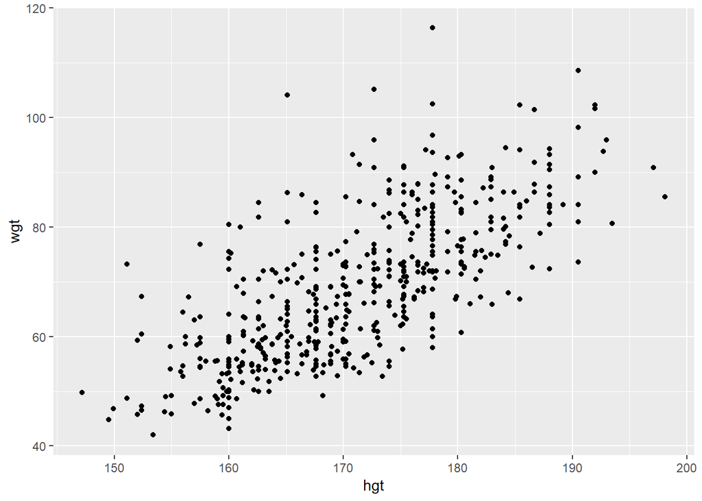

```r
ggplot(data = bdims, aes(x = hgt, y = wgt)) +
  geom_point()
```

# 28 Add the line to the scatterplot

```r
ggplot(data = bdims, aes(x = hgt, y = wgt)) +
  geom_point() +
  geom_abline(data = coefs_df,
              aes(intercept = `(Intercept)`, slope = hgt),
              color = "dodgerblue")
```

[output not shown]

# 29 Assessing model fit

- now that we know what linear models are and how they work the next question to consider is how well they work?
- in an intuitive sense it seems clear that the regression line for the textbooks fits really well and the same the regression line for the possums fits less well but still seems useful
- can we quantify our intuition about the quality of the model fit
- infact we can
- recall that we initially considered any number of lines
- we settled on the unique regression line by applying the least squares criteria
- that is we found the line the minimizes the sum of the squares of the residuals for each observation which is represented on the scatter plot by a point
- the residual is simply the verticle distance of that point from the line

Regression line for textbooks fits really well

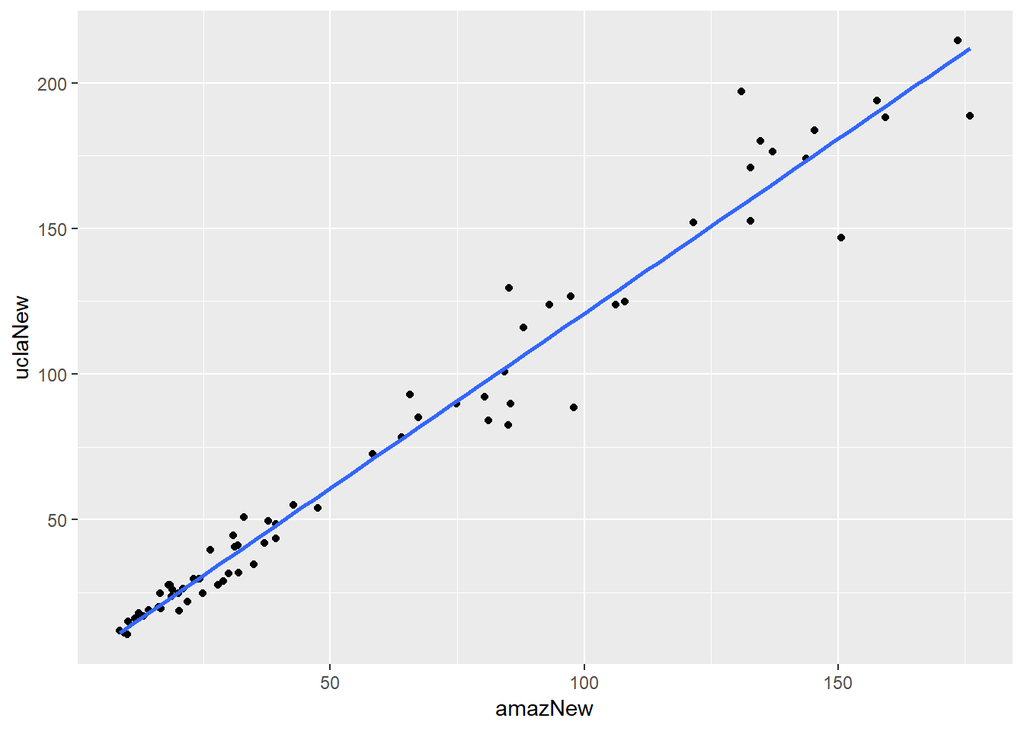

```r
ggplot(data = textbooks, aes(x = amazNew, y = uclaNew)) +
  geom_point() + geom_smooth(method = 'lm', se = FALSE)
```

Whereas for possums regression line fits less well becasue many points are scattered away from the line

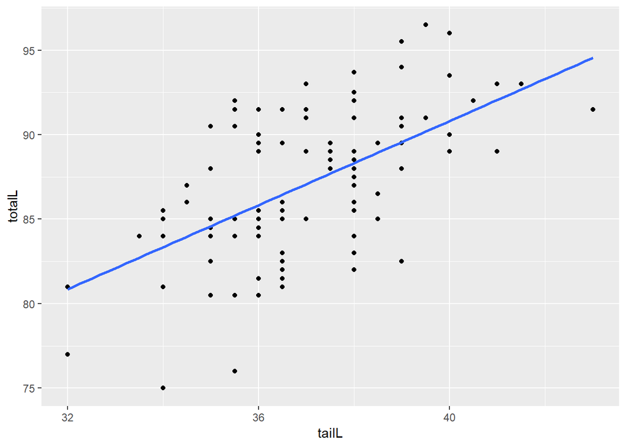

```r
ggplot(data = possum, aes(y = totalL, x = tailL)) +
  geom_point() + geom_smooth(method = 'lm', se = FALSE)
```

Quality of line can be determined by sums of squared deviations residual is verticle distance of the point from the line since positive and negative residuals always cancle each other out we square them and use the sum of the squares SSE but it penalizes large residuals disproporionately

```r
library(broom)

mod_possum = lm(totalL ~ tailL, data = possum)

mod_possum %>%
  augment() %>%
  summarize(SSE = sum(.resid^2),
            SSE_also = (n() - 1) * var(.resid))
```

```
##        SSE SSE_also
## 1 1301.488 1301.488
```

This is generally considered a useful property for statistical modeling. Sine you would always prefer a model that misses by a little bit but never by a line

# 30 SSE is sum of squared errors

- it is the single number that measures how much our model missed by
- it can be computed by using both above formulas in the summarise
- unfortunately it is hard to interprete since the units have been squared
- so we use RMSE root mean squared error that is square root of SSE by square root of number of observations minu 2
- n-2 is the decreasing freedom
- when R displays the summary of linear model, the Residual standard error is the RMSE

```r
summary(mod_possum)
```

```
##
## Call:
## lm(formula = totalL ~ tailL, data = possum)
##
## Residuals:
##     Min      1Q  Median      3Q     Max
## -9.2100 -2.3265  0.1792  2.7765  6.7900
##
## Coefficients:
##             Estimate Std. Error t value Pr(>|t|)
## (Intercept)  41.0371     6.6568   6.165 1.43e-08 ***
## tailL         1.2443     0.1796   6.927 3.94e-10 ***
## ---
## Signif. codes:  0 '***' 0.001 '**' 0.01 '*' 0.05 '.' 0.1 ' ' 1
##
## Residual standard error: 3.572 on 102 degrees of freedom
## Multiple R-squared:   0.32,  Adjusted R-squared:  0.3133
## F-statistic: 47.99 on 1 and 102 DF,  p-value: 3.935e-10
```

```r
# summary of response variable
summary(possum$totalL)
```

```
##    Min. 1st Qu.  Median    Mean 3rd Qu.    Max.
##   75.00   84.00   88.00   87.09   90.00   96.50
```

Residual standard error is 3.57

- RMSE is in the units of the response
- therefore 3.57 is in cms

```r
mod_textbook = lm(uclaNew ~ amazNew, data = textbooks)

mod_possum %>%
  augment() %>%
  summarize(SSE = sum(.resid^2),
            SSE_also = (n() - 1) * var(.resid))
```

```
##        SSE SSE_also
## 1 1301.488 1301.488
```

```r
summary(mod_textbook)
```

```
##
## Call:
## lm(formula = uclaNew ~ amazNew, data = textbooks)
##
## Residuals:
##     Min      1Q  Median      3Q     Max
## -34.785  -4.574   0.577   4.012  39.002
##
## Coefficients:
##             Estimate Std. Error t value Pr(>|t|)
## (Intercept)  0.92897    1.93538    0.48    0.633
## amazNew      1.19900    0.02519   47.60   <2e-16 ***
## ---
## Signif. codes:  0 '***' 0.001 '**' 0.01 '*' 0.05 '.' 0.1 ' ' 1
##
## Residual standard error: 10.47 on 71 degrees of freedom
## Multiple R-squared:  0.9696, Adjusted R-squared:  0.9692
## F-statistic:  2266 on 1 and 71 DF,  p-value: < 2.2e-16
```

```r
summary(textbooks$ucla)
```

```
##    Min. 1st Qu.  Median    Mean 3rd Qu.    Max.
##   10.50   24.70   43.56   72.22  116.00  214.50
```

Residual standard error is 10.47 USD

- which is quite high eventhough we saw the regression line fit from ggplot was better than that of possum line fit
- but is it right to compare 3.57 cm to 10.47 USDs
- we’ll need a better way to compare

# 31 RMSE

The residual standard error reported for the regression model for poverty rate of U.S. counties in terms of high school graduation rate is 4.67. What does this mean?

ANSWER THE QUESTION

Possible Answers The typical difference between the observed poverty rate and the poverty rate predicted by the model is about 4.67 percentage points. (answer - residual standard error is in units of repsonse variable. Here model is definded for poverty rate in terms of higch school graducaiton rate)

The typical difference between the observed poverty rate and the poverty rate predicted by the model is about 4.67%.

The model explains about 4.67% of the variability in poverty rate among counties.

The model correctly predicted the poverty rate of 4.67% of the counties.

# 32 Standard error of residuals

- one way to assess strength of fit is to consider how far off the model is for a typical case
- that is for some observations the fitted value will be very close to the actual value, while for others it will not
- the magnitude of a typical residual can give us a sense of generally how close our estimates are

However, recall that some of the residuals are positive whilte others are negative. In fact, it is guaranteed by the least squares fitting procedure that the mean of the residuals is zero

- thus it makes more sense to compute the square root of the mean squared residual or root mean squared error (RMSE)
- R calls this quantity the residual standard error

You can recover the residuals from mod with residuals(), and the degrees of freedom with df.residual().

```r
mod_bdims = lm( wgt ~ hgt, data = bdims)

# View summary of model
summary(mod_bdims)
```

```
##
## Call:
## lm(formula = wgt ~ hgt, data = bdims)
##
## Residuals:
##     Min      1Q  Median      3Q     Max
## -18.743  -6.402  -1.231   5.059  41.103
##
## Coefficients:
##               Estimate Std. Error t value Pr(>|t|)
## (Intercept) -105.01125    7.53941  -13.93   <2e-16 ***
## hgt            1.01762    0.04399   23.14   <2e-16 ***
## ---
## Signif. codes:  0 '***' 0.001 '**' 0.01 '*' 0.05 '.' 0.1 ' ' 1
##
## Residual standard error: 9.308 on 505 degrees of freedom
## Multiple R-squared:  0.5145, Adjusted R-squared:  0.5136
## F-statistic: 535.2 on 1 and 505 DF,  p-value: < 2.2e-16
```

```r
# Compute the mean of the residuals
mean(residuals(mod_bdims))
```

```
## [1] -1.266971e-15
```

```r
# Compute RMSE
sqrt(sum(residuals(mod_bdims)^2) /df.residual(mod_bdims) )
```

```
## [1] 9.30804
```

# 33 Comparing model fits

Coefficient of determination * usaully referred to as R squared

R square = 1 minus SSE/SST = 1 - Var(e)/Var(y)

- due to this definition we interpret R squared as the proportion of the variability in the response variable that has explained by our model
- it is the most cited measure of the quality of fit of a regression model

Connection to correlation

- we have already seen a connection between the value of correlation of x,y and the value of the slope of the regression line
- correlation coeff is also closely related to R squared
- corr squared = R squared
- then why we need both concepts
- correlation is strictly a bivariate quantity it can only be between a single response and a single explanatory variable
- however, regression is a much more flexible model and framework
- each regression model has it’s own value of R squared and there are other models that can accomodate many explanatory variables unlike correlation
- in summary output of model object
- Multiple R-squared gives us the R-squared value in case of possums it is 0.32, meaning, our model based on tail length explains 32 % variability in body life of these possums

Over-reliance of R-squared * a high R squared doesn’t mean you have a good model and a low R squared doesn’t mean you have a lousy model * high R squared could be due to overfit model or may violate the conditions for inference that we will discuss in the later chapter * a model with low R squared can still provide statistically significant insight into a complex problem * quote by famous statistician George Box

‘Essentially, all models are wrong, but some are useful’ * George Box

```r
model_null = lm(totalL ~ 1, data = possum)

model_null %>%
  augment(possum) %>%
  summarize(SST = sum(.resid^2))
```

```
##        SST
## 1 1913.826
```

```r
# compare this with mod_possum using tailL explanatory variable

model_null = lm(totalL ~ tailL, data = possum)

model_null %>%
  augment(possum) %>%
  summarize(SST = sum(.resid^2))
```

```
##        SST
## 1 1301.488
```

# 34 Assessing simple linear model fit

```r
bdims_tidy = augment(mod_bdims)

str(bdims_tidy)
```

```
## 'data.frame':    507 obs. of  9 variables:
##  $ wgt       : num  65.6 71.8 80.7 72.6 78.8 74.8 86.4 78.4 62 81.6 ...
##  $ hgt       : num  174 175 194 186 187 ...
##  $ .fitted   : num  72.1 73.4 91.9 84.8 85.5 ...
##  $ .se.fit   : num  0.432 0.452 1.067 0.792 0.818 ...
##  $ .resid    : num  -6.45 -1.58 -11.2 -12.17 -6.69 ...
##  $ .hat      : num  0.00215 0.00236 0.01313 0.00724 0.00773 ...
##  $ .sigma    : num  9.31 9.32 9.3 9.3 9.31 ...
##  $ .cooksd   : num  0.00052 0.000034 0.009758 0.006282 0.002026 ...
##  $ .std.resid: num  -0.694 -0.17 -1.211 -1.313 -0.721 ...
```

```r
#Use the summary() function to view the full results of mod.
summary(mod_bdims)
```

```
##
## Call:
## lm(formula = wgt ~ hgt, data = bdims)
##
## Residuals:
##     Min      1Q  Median      3Q     Max
## -18.743  -6.402  -1.231   5.059  41.103
##
## Coefficients:
##               Estimate Std. Error t value Pr(>|t|)
## (Intercept) -105.01125    7.53941  -13.93   <2e-16 ***
## hgt            1.01762    0.04399   23.14   <2e-16 ***
## ---
## Signif. codes:  0 '***' 0.001 '**' 0.01 '*' 0.05 '.' 0.1 ' ' 1
##
## Residual standard error: 9.308 on 505 degrees of freedom
## Multiple R-squared:  0.5145, Adjusted R-squared:  0.5136
## F-statistic: 535.2 on 1 and 505 DF,  p-value: < 2.2e-16
```

Use the bdims_tidy data frame to compute the R2 of mod manually using the formula above, by computing the ratio of the variance of the residuals to the variance of the response variable.

```r
names(bdims_tidy)
```

```
## [1] "wgt"        "hgt"        ".fitted"    ".se.fit"    ".resid"
## [6] ".hat"       ".sigma"     ".cooksd"    ".std.resid"
```

```r
# Compute R-squared
bdims_tidy %>%
  summarize(var_y = var(wgt),
            var_e = var(.resid)) %>%
  mutate(R_squared = 1- var_e/var_y)
```

```
##      var_y    var_e R_squared
## 1 178.1094 86.46839 0.5145208
```

Conlcusion: Compare with summary output - Multiple R-squared: 0.5145

Great work! This means that 51.4% of the variability in weight is explained by height.

# 35 Interpretation of R^2

The R2 reported for the regression model for poverty rate of U.S. counties in terms of high school graduation rate is 0.464.

lm(formula = poverty ~ hs_grad, data = countyComplete) %>% summary()

How should this result be interpreted?

{ R squared - explains how much variability in poverty is explained by hs_grad }

Possible Answers 46.4% of the variability in high school graduate rate among U.S. counties can be explained by poverty rate.

46.4% of the variability in poverty rate among U.S. counties can be explained by high school graduation rate. (answer)

This model is 46.4% effective.

The correlation between poverty rate and high school graduation rate is 0.464.

# 36 Linear vs. average

It may be useful to preview these augment()-ed data frames with glimpse():

glimpse(mod_null) glimpse(mod_hgt)

```r
# fitting a null model by setting explanatory varaibel to 1
mod_null_bdims = lm( wgt ~ 1, data = bdims)

summary(mod_null_bdims)
```

```
##
## Call:
## lm(formula = wgt ~ 1, data = bdims)
##
## Residuals:
##     Min      1Q  Median      3Q     Max
## -27.148 -10.748  -0.948   9.702  47.252
##
## Coefficients:
##             Estimate Std. Error t value Pr(>|t|)
## (Intercept)  69.1475     0.5927   116.7   <2e-16 ***
## ---
## Signif. codes:  0 '***' 0.001 '**' 0.01 '*' 0.05 '.' 0.1 ' ' 1
##
## Residual standard error: 13.35 on 506 degrees of freedom
```

```r
mod_null_bdims_tidy = mod_null_bdims %>%
  augment()

names(mod_null_bdims_tidy)
```

```
## [1] "wgt"        ".fitted"    ".se.fit"    ".resid"     ".hat"
## [6] ".sigma"     ".cooksd"    ".std.resid"
```

```r
#Compute the sum of the squared residuals (SSE) for the null model mod_null

mod_null_bdims_tidy %>%
  summarize(SSE = var(.resid))
```

```
##        SSE
## 1 178.1094
```

```r
# fitting a linear regression model to explain vaiability in wgt wrt hgt
mod_hgt_bdims = lm( wgt ~ hgt, data = bdims)

summary(mod_hgt_bdims)
```

```
##
## Call:
## lm(formula = wgt ~ hgt, data = bdims)
##
## Residuals:
##     Min      1Q  Median      3Q     Max
## -18.743  -6.402  -1.231   5.059  41.103
##
## Coefficients:
##               Estimate Std. Error t value Pr(>|t|)
## (Intercept) -105.01125    7.53941  -13.93   <2e-16 ***
## hgt            1.01762    0.04399   23.14   <2e-16 ***
## ---
## Signif. codes:  0 '***' 0.001 '**' 0.01 '*' 0.05 '.' 0.1 ' ' 1
##
## Residual standard error: 9.308 on 505 degrees of freedom
## Multiple R-squared:  0.5145, Adjusted R-squared:  0.5136
## F-statistic: 535.2 on 1 and 505 DF,  p-value: < 2.2e-16
```

```r
# tidying the linear model to get the coeffs and other measures in a data frame

mod_hgt_bdims_tidy = mod_hgt_bdims %>%
  augment()

names(mod_hgt_bdims_tidy)
```

```
## [1] "wgt"        "hgt"        ".fitted"    ".se.fit"    ".resid"
## [6] ".hat"       ".sigma"     ".cooksd"    ".std.resid"
```

```r
# Compute (SSE) for the regression model mod_hgt

mod_hgt_bdims_tidy %>%
  summarize(SSE = var(.resid))
```

```
##        SSE
## 1 86.46839
```

# 37 Unusual points

```r
regulars = mlbBat10 %>%
  filter(AB > 400)
```

Scatter plot for bivariate relationship between SB and HR also regression line to see type of relationship

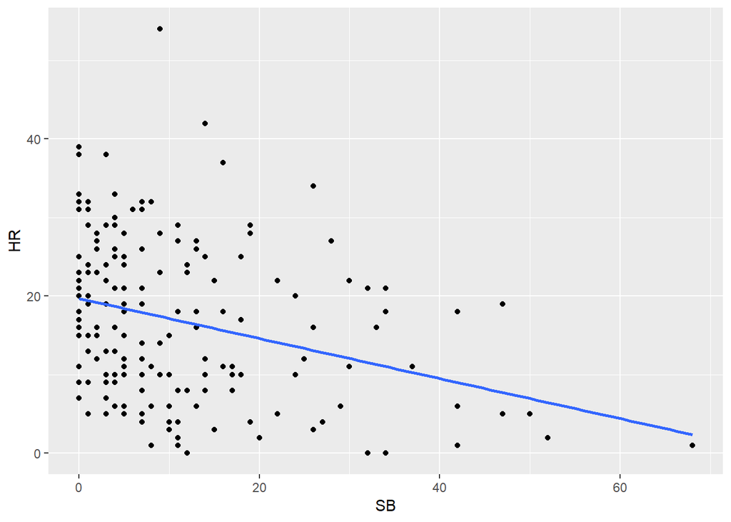

```r
ggplot(regulars, aes(x = SB, y = HR)) +
  geom_point() +
  geom_smooth(method = "lm", se = 0)
```

- the top left point is outlier corresponding to player Jose Bautista and lower right to Juan Pierre
- we might want to know how a point influences the slope of the regression line
- the purpose of interpreting the slope coefficient is to learn about the over all reltionship between the two variables
- so it doesn’t necessarily make sense if one or two individual observations have a disproporitionate effect on the slope
- the concept of leverage and influence will help us quantify this intuition

# 38 Leverage { based on explanatory variable, higher x higher leverage}

```r
#library(broom)

mod_mlbat10 = lm(HR ~ SB, data = regulars)

mod_mlbat10_tidy = mod_mlbat10 %>%
  augment()

names(mod_mlbat10_tidy)
```

```
## [1] "HR"         "SB"         ".fitted"    ".se.fit"    ".resid"
## [6] ".hat"       ".sigma"     ".cooksd"    ".std.resid"
```

```r
mod_mlbat10_tidy  %>%
  arrange(desc(.hat)) %>%
  select(HR, SB, .fitted, .resid, .hat) %>%
  head()
```

```
##   HR SB  .fitted    .resid       .hat
## 1  1 68 2.382748 -1.382748 0.13081869
## 2  2 52 6.461361 -4.461361 0.07033516
## 3  5 50 6.971187 -1.971187 0.06416940
## 4 19 47 7.735927 11.264073 0.05550188
## 5  5 47 7.735927 -2.735927 0.05550188
## 6  1 42 9.010493 -8.010493 0.04260564
```

# 39 Leverage

The leverage of an observation in a regression model is defined entirely in terms of the distance of that observation from the mean of the explanatory variable. That is, observations close to the mean of the explanatory variable have low leverage, while observations far from the mean of the explanatory variable have high leverage. Points of high leverage may or may not be influential.

The augment() function from the broom package will add the leverage scores (.hat) to a model data frame.

Use augment() to list the top 6 observations by their leverage scores, in descending order.

Rank points of high leverage

```r
mod %>%
  augment() %>%
  arrange(desc(.hat)) %>%
  head()
```

```
##    wgt   hgt  .fitted  .se.fit     .resid       .hat   .sigma      .cooksd
## 1 85.5 198.1 96.57863 1.255712 -11.078629 0.01819968 9.303950 0.0133734319
## 2 90.9 197.1 95.56101 1.214264  -4.661012 0.01701803 9.314916 0.0022081690
## 3 49.8 147.2 44.78194 1.131432   5.018065 0.01477545 9.314548 0.0022120570
## 4 80.7 193.5 91.89759 1.066733 -11.197592 0.01313394 9.303732 0.0097584634
## 5 95.9 193.0 91.38878 1.046493   4.511216 0.01264027 9.315075 0.0015228117
## 6 44.8 149.5 47.12245 1.037916  -2.322454 0.01243391 9.316688 0.0003968468
##   .std.resid
## 1 -1.2012024
## 2 -0.5050673
## 3  0.5431383
## 4 -1.2109808
## 5  0.4877505
## 6 -0.2510763
```

# 40 Influence

As noted previously, observations of high leverage may or may not be influential. The influence of an observation depends not only on its leverage, but also on the magnitude of its residual. Recall that while leverage only takes into account the explanatory variable (x), the residual depends on the response variable (y) and the fitted value (y^).

Influential points are likely to have high leverage and deviate from the general relationship between the two variables. We measure influence using Cook’s distance, which incorporates both the leverage and residual of each observation.

Use augment() to list the top 6 observations by their Cook’s distance (.cooksd), in descending order.

Rank influential points

```r
mod %>%
  augment() %>%
  arrange(desc(.cooksd)) %>%
  head()
```

```
##     wgt   hgt  .fitted   .se.fit   .resid        .hat   .sigma    .cooksd
## 1  73.2 151.1 48.75064 0.9737632 24.44936 0.010944356 9.252694 0.03859555
## 2 116.4 177.8 75.92101 0.5065670 40.47899 0.002961811 9.140611 0.02817388
## 3 104.1 165.1 62.99728 0.4914889 41.10272 0.002788117 9.135102 0.02733574
## 4 108.6 190.5 88.84474 0.9464667 19.75526 0.010339372 9.275186 0.02377609
## 5  67.3 152.4 50.07354 0.9223084 17.22646 0.009818289 9.285305 0.01714950
## 6  76.8 157.5 55.26339 0.7287405 21.53661 0.006129560 9.267446 0.01661032
##   .std.resid
## 1   2.641185
## 2   4.355274
## 3   4.421999
## 4   2.133444
## 5   1.859860
## 6   2.320888
```

# 41 Dealing with unusal points

- leverage and influence help us measure how outliers afffect our model
- suppose you have determined that an influential observation is affecting the slope of your regression line in a way that undermines the scientific merit of your model
- what can you do about it
- short answer is nothing much other than removing the outlier
- as the statistical modeler this is a decision that you can make but it’s crucial that you understand the ramifications of this decision and act in a good scientific way
- the long answer is that there are more sophisticated statistical techniques that we won’t discuss in this course
- anytime you are removing outliers you should ask yourself:

## 41.1 1. What the justification is?

- because it improves my results is not a good justification
- indeed conscious ignorance of valid data is not intellectually honest and has been the cause of a more than few retractions of previously published scientific papers
- be skeptical, the burden of proof is on you to make as strong argument as to why data should be imitted

## 41.2 2. How does the scope of inference change?

- you must consider how this changes the scope of inference
- if you’re studying countries, you must consider are you omitting the poorest countries
- if so then your results don’t apply to all countries but just non-poor countries
- misunderstanding how the scope if inference changes can be a fatal flaw in your analysis
- with Henderson out of the way consider removing Juan Pierre as well
- here there isn’t any good argument as to why this should be done
- it’s non-influential, that is whether we remove it or not is not going to make much of a difference
- only if Juan Pierre was an unusaul case you could make an argument to remove his data

# 42 Removing outliers

Observations can be outliers for a number of different reasons. Statisticians must always be careful-and more importantly, transparent-when dealing with outliers. Sometimes, a better model fit can be achieved by simply removing outliers and re-fitting the model. However, one must have strong justification for doing this. A desire to have a higher R2 is not a good enough reason!

In the mlbBat10 data, the outlier with an OBP of 0.550 is Bobby Scales, an infielder who had four hits in 13 at-bats for the Chicago Cubs. Scales also walked seven times, resulting in his unusually high OBP. The justification for removing Scales here is weak. While his performance was unusual, there is nothing to suggest that it is not a valid data point, nor is there a good reason to think that somehow we will learn more about Major League Baseball players by excluding him.

Nevertheless, we can demonstrate how removing him will affect our model.

Use filter() to create a subset of mlbBat10 called nontrivial_players consisting of only those players with at least 10 at-bats and OBP of below 0.500.

```r
names(mlbBat10)
```

```
##  [1] "name"     "team"     "position" "G"        "AB"       "R"
##  [7] "H"        "2B"       "3B"       "HR"       "RBI"      "TB"
## [13] "BB"       "SO"       "SB"       "CS"       "OBP"      "SLG"
## [19] "AVG"
```

```r
nontrivial_players = mlbBat10 %>%
  filter(AB >= 10, OBP < 0.500)

nrow(mlbBat10)
```

```
## [1] 1199
```

```r
nrow(nontrivial_players)
```

```
## [1] 736
```

Fit the linear model for SLG as a function of OBP for the nontrivial_players. Save the result as mod_cleaner.

```r
mod_cleaner = nontrivial_players %>%
  lm(SLG ~ OBP, data = .)
```

View the summary() of the new model and compare the slope and R2 to those of mod, the original model fit to the data on all players.

```r
summary(mod_cleaner)
```

```
##
## Call:
## lm(formula = SLG ~ OBP, data = .)
##
## Residuals:
##      Min       1Q   Median       3Q      Max
## -0.31383 -0.04165 -0.00261  0.03992  0.35819
##
## Coefficients:
##              Estimate Std. Error t value Pr(>|t|)
## (Intercept) -0.043326   0.009823  -4.411 1.18e-05 ***
## OBP          1.345816   0.033012  40.768  < 2e-16 ***
## ---
## Signif. codes:  0 '***' 0.001 '**' 0.01 '*' 0.05 '.' 0.1 ' ' 1
##
## Residual standard error: 0.07011 on 734 degrees of freedom
## Multiple R-squared:  0.6937, Adjusted R-squared:  0.6932
## F-statistic:  1662 on 1 and 734 DF,  p-value: < 2.2e-16
```

```r
mlbBat10 %>%
  lm(formula = SLG ~ OBP, data = .) %>%
  summary()
```

```
##
## Call:
## lm(formula = SLG ~ OBP, data = .)
##
## Residuals:
##      Min       1Q   Median       3Q      Max
## -1.11973 -0.02002 -0.00941  0.03129  2.88027
##
## Coefficients:
##             Estimate Std. Error t value Pr(>|t|)
## (Intercept) 0.009407   0.006141   1.532    0.126
## OBP         1.110323   0.022854  48.583   <2e-16 ***
## ---
## Signif. codes:  0 '***' 0.001 '**' 0.01 '*' 0.05 '.' 0.1 ' ' 1
##
## Residual standard error: 0.137 on 1197 degrees of freedom
## Multiple R-squared:  0.6635, Adjusted R-squared:  0.6632
## F-statistic:  2360 on 1 and 1197 DF,  p-value: < 2.2e-16
```

non-trivial vs original slope - OBP - 1.34 vs 1.11 R squred - 0.69 vs 0.66

Visualize the new model with ggplot() and the appropriate geom_*() functions.

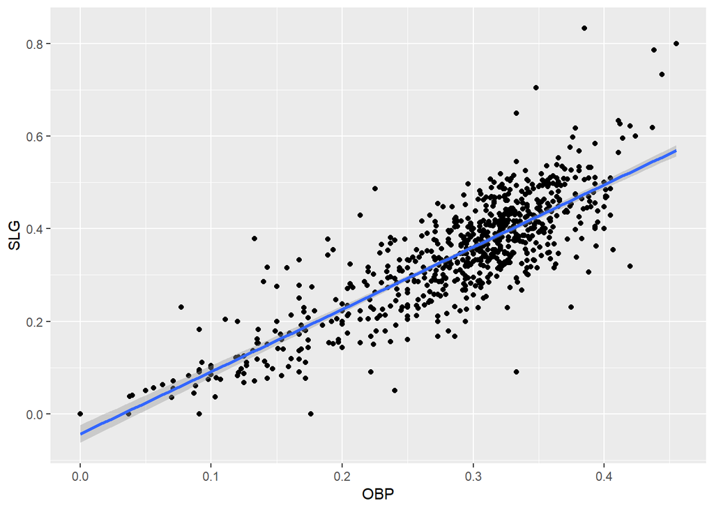

```r
ggplot(nontrivial_players, aes(x = OBP, y = SLG)) +
  geom_point() +
  geom_smooth(method = "lm")
```

High leverage points Not all points of high leverage are influential. While the high leverage observation corresponding to Bobby Scales in the previous exercise is influential, the three observations for players with OBP and SLG values of 0 are not influential.

This is because they happen to lie right near the regression anyway. Thus, while their extremely low OBP gives them the power to exert influence over the slope of the regression line, their low SLG prevents them from using it.

```r
mod_obg = lm(SLG ~ OBP, data = filter(mlbBat10, AB >= 10))

summary(mod_obg)
```

```
##
## Call:
## lm(formula = SLG ~ OBP, data = filter(mlbBat10, AB >= 10))
##
## Residuals:
##      Min       1Q   Median       3Q      Max
## -0.38249 -0.04085 -0.00202  0.03927  0.36089
##
## Coefficients:
##              Estimate Std. Error t value Pr(>|t|)
## (Intercept) -0.037446   0.009957  -3.761 0.000183 ***
## OBP          1.323522   0.033408  39.617  < 2e-16 ***
## ---
## Signif. codes:  0 '***' 0.001 '**' 0.01 '*' 0.05 '.' 0.1 ' ' 1
##
## Residual standard error: 0.0715 on 735 degrees of freedom
## Multiple R-squared:  0.6811, Adjusted R-squared:  0.6806
## F-statistic:  1570 on 1 and 735 DF,  p-value: < 2.2e-16
```

The linear model, mod, is available in your workspace. Use a combination of augment(), arrange() with two arguments, and head() to find the top 6 observations with the highest leverage but the lowest Cook’s distance.

```r
mod_obg %>%
  augment() %>%
  arrange(desc(.hat), .cooksd) %>%
  head()
```

```
##     SLG   OBP     .fitted     .se.fit      .resid       .hat     .sigma
## 1 0.000 0.000 -0.03744579 0.009956861  0.03744579 0.01939493 0.07153050
## 2 0.000 0.000 -0.03744579 0.009956861  0.03744579 0.01939493 0.07153050
## 3 0.000 0.000 -0.03744579 0.009956861  0.03744579 0.01939493 0.07153050
## 4 0.308 0.550  0.69049108 0.009158810 -0.38249108 0.01641049 0.07011360
## 5 0.000 0.037  0.01152451 0.008770891 -0.01152451 0.01504981 0.07154283
## 6 0.038 0.038  0.01284803 0.008739031  0.02515197 0.01494067 0.07153800
##        .cooksd .std.resid
## 1 0.0027664282  0.5289049
## 2 0.0027664282  0.5289049
## 3 0.0027664282  0.5289049
## 4 0.2427446800 -5.3943121
## 5 0.0002015398 -0.1624191
## 6 0.0009528017  0.3544561
```

Fantastic! Congratulations on finishing the last exercise of the course!

- this course was about analysing the relationship between two numeric variables
- we’ve learned a variety of techniques for doing this
- first we explored how powerful scatter plots can be in revealing bivariate relationships in intuitive graphical form
- we built a framework in describing what we see in those scatter plots and practised implementing that framework on real data
- second we learned about correlation
- a simple way to quantify a simple linear relationship between two variables using a single number
- but careless application of this can result in errorneous results
- third we learned about linear regression a relatively simple yet powerful technique for modeling a response variable in terms of a single explanatory variable
- we built our intuition about how these models work and identified some of their key properties
- fourth we focused carefully on how to interpret the coefficients of regression model and how those coefficients can bring real insights into complex problems
- we also developed a foundational understanding of how to build these models in R
- and how to work with them afterwards
- finally we introduced the notion of model fit and developed tools to help us reason about the quality of our models
- and how much we can learn from them
- together you should be able to establish unravel relationships between variables with these tools